# Final_MosesKrystina

Krystina Moses

06/01/2019

# Statistics for Data Science Final

For all of the datasets, I limited the data to what I was interested in analyzing and by removing all the unneeded values for comparison.

**Black Friday**

Dataset

```
## blackfriday
##
##  12  Variables      537577  Observations
## ---------------------------------------------------------------------------
## User_ID
##        n  missing distinct     Info     Mean      Gmd      .05      .10
##   537577        0     5891        1  1002992     1979  1000325  1000659
##      .25      .50      .75      .90      .95
##  1001495  1003031  1004417  1005402  1005724
##
## lowest : 1000001 1000002 1000003 1000004 1000005
## highest: 1006036 1006037 1006038 1006039 1006040
## ---------------------------------------------------------------------------
## Product_ID
##        n  missing distinct
##   537577        0     3623
##
## lowest : P00000142 P00000242 P00000342 P00000442 P00000542
## highest: P0099442  P0099642  P0099742  P0099842  P0099942
## ---------------------------------------------------------------------------
## Gender
##        n  missing distinct
##   537577        0        2
##
## Value           F      M
## Frequency  132197 405380
## Proportion  0.246  0.754
## ---------------------------------------------------------------------------
## Age
##        n  missing distinct
##   537577        0        7
##
## Value        0-17  18-25  26-35  36-45  46-50  51-55    55+
## Frequency   14707  97634 214690 107499  44526  37618  20903
## Proportion  0.027  0.182  0.399  0.200  0.083  0.070  0.039
## ---------------------------------------------------------------------------
## Occupation
##        n  missing distinct     Info     Mean      Gmd      .05      .10
##   537577        0       21    0.993    8.083    7.392        0        0
##      .25      .50      .75      .90      .95
```

[output cut: 60 more lines]

```
## Frequency    600  1840 16380  4818 12384 11414  1698  1773  9094  5385
## Proportion 0.004 0.011 0.100 0.029 0.075 0.069 0.010 0.011 0.055 0.033
##
## Value         14    15    16    17    18
## Frequency  18121 27611 32148 16449  4563
## Proportion 0.110 0.168 0.196 0.100 0.028
## ---------------------------------------------------------------------------
## Purchase
##        n  missing distinct     Info     Mean      Gmd      .05      .10
##   537577        0    17959        1     9334     5560     2096     3608
##      .25      .50      .75      .90      .95
##     5866     8062    12073    16337    19342
##
## lowest :   185   186   187   188   189, highest: 23956 23958 23959 23960 23961
## ---------------------------------------------------------------------------
```

```
## [1] "data.frame"
```

```
##  [1] "User_ID"                    "Product_ID"
##  [3] "Gender"                     "Age"
##  [5] "Occupation"                 "City_Category"
##  [7] "Stay_In_Current_City_Years" "Marital_Status"
##  [9] "Product_Category_1"         "Product_Category_2"
## [11] "Product_Category_3"         "Purchase"
```

```
##    Gender   Age Purchase
## 1       F  0-17     8370
## 2       F  0-17    15200
## 3       F  0-17     1422
## 4       F  0-17     1057
## 5       M   55+     7969
## 6       M 26-35    15227
## 7       M 46-50    19215
## 8       M 46-50    15854
## 9       M 46-50    15686
## 10      M 26-35     7871
```

```
##        Gender   Age Purchase
## 537568      M 18-25     1994
## 537569      M 18-25     5930
## 537570      M 18-25     7042
## 537571      M 18-25    15491
## 537572      M 36-45    11852
## 537573      M 36-45    11664
## 537574      M 36-45    19196
## 537575      M 36-45     8043
## 537576      M 36-45     7172
## 537577      M 36-45     6875
```

*What is the spending amount compared to the age of the shopper*

I found the average purchases total was $9333.86 by calculating the mean of the column. Around the average purchase, there were less of the age group 55+; however, there was still no one that stood out as being a top hit for the analysis. The graph I plotted to assist with visual understanding did not show any change/significance as it was all lines that showed no significant changes with the categories of data.

Average Purchase

```
## [1] 9333.86
```

The limitations of the data were there was not enough to go by. I believe additional categories would have been helpful to analyze further of what age groups are shopping for to add up to the total purchases made. It could be built on by analyzing it further with the additional yearly data as well for particular stores.

Graphs

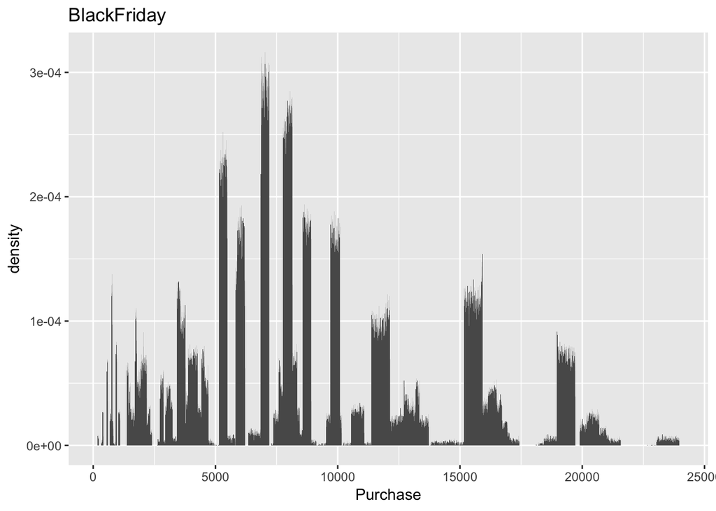

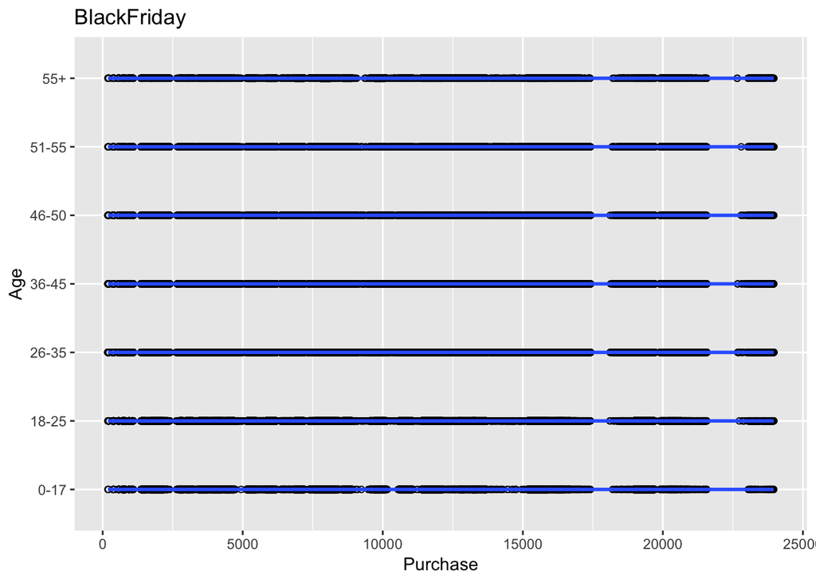

**Hockey**

Dataset

```
## hockey
##
##  17  Variables      927  Observations
## ---------------------------------------------------------------------------
## year
##        n  missing distinct     Info     Mean      Gmd      .05      .10
##      927        0       97        1     1976    28.51     1925     1933
##      .25      .50      .75      .90      .95
##     1963     1982     1996     2006     2009
##
## lowest : 1913 1914 1916 1917 1918, highest: 2007 2008 2009 2010 2011
## ---------------------------------------------------------------------------
## lgID
##        n  missing distinct
##      927        0        5
##
## Value        NHA   NHL  PCHA  WCHL   WHA
## Frequency      6   841    14    13    53
## Proportion 0.006 0.907 0.015 0.014 0.057
## ---------------------------------------------------------------------------
## tmID
##        n  missing distinct
##      927        0       77
##
## lowest : ANA AND ATF ATL BIR, highest: VIC VML WAS WIJ WIN
## ---------------------------------------------------------------------------
## G
##        n  missing distinct     Info     Mean      Gmd      .05      .10
##      927        0       25    0.994    8.809    6.071        2        3
##      .25      .50      .75      .90      .95
##        5        7       12       18       20
##
## lowest :  2  3  4  5  6, highest: 22 23 24 25 26
## ---------------------------------------------------------------------------
## W
##        n  missing distinct     Info     Mean      Gmd      .05      .10
##      927        0       17    0.987    4.367    4.443      0.0      0.0
##      .25      .50      .75      .90      .95
##      1.0      3.0      7.0     11.0     13.7
##
```

[output cut: 101 more lines]

```
## ---------------------------------------------------------------------------
## SHF
##        n  missing distinct     Info     Mean      Gmd      .05      .10
##      636      291       11    0.887    1.145    1.466        0        0
##      .25      .50      .75      .90      .95
##        0        1        2        3        4
##
## Value          0     1     2     3     4     5     6     7     8     9
## Frequency    283   180    80    41    23    14     8     4     1     1
## Proportion 0.445 0.283 0.126 0.064 0.036 0.022 0.013 0.006 0.002 0.002
##
## Value         10
## Frequency      1
## Proportion 0.002
## ---------------------------------------------------------------------------
```

```
## [1] "data.frame"
```

```
##  [1] "year"       "lgID"       "tmID"       "G"          "W"
##  [6] "L"          "T"          "GF"         "GA"         "PIM"
## [11] "BenchMinor" "PPG"        "PPC"        "SHA"        "PKG"
## [16] "PKC"        "SHF"
```

```
##    year G W L T GF GA
## 1  1913 2 1 1 0  2  6
## 2  1913 2 1 1 0  6  2
## 3  1914 2 1 1 0  1  4
## 4  1914 2 1 1 0  4  1
## 5  1916 2 1 1 0  7  6
## 6  1916 2 1 1 0  6  7
## 7  1917 2 1 1 0  7 10
## 8  1917 2 1 1 0 10  7
## 9  1917 2 0 1 1  2  3
## 10 1917 2 1 0 1  3  2
```

```
##     year  G  W  L T GF GA
## 918 2011 24 14 10 0 59 58
## 919 2011 20 10 10 0 43 41
## 920 2011  7  3  4 0 13 14
## 921 2011 11  5  6 0 41 44
## 922 2011 16  9  7 0 37 35
## 923 2011  6  2  4 0 26 30
## 924 2011  5  1  4 0  8 14
## 925 2011  9  4  5 0 20 23
## 926 2011  5  1  4 0  8 12
## 927 2011 14  7  7 0 29 30
```

Average Goals For

```
## [1] 25.60194
```

Average Goals Against

```
## [1] 25.60194
```

*How do the goals for and against compare within the wins/losses*

While analyzing the data I was most interested in seeing how the goals changed for the number of wins and losses over the different years. I used graphs and calculations of the averages to analyze the trends. The average goals for and goals against was calculated to 25.6.

Overall, I found that in the year 1918, the total number of games as 5 and when there were 4 wins vs 1 loss, there was a higher goals for amount than against. When sorting the data from highest amount of goals for, it is shown that this was in the year of 1984; however, the big difference is the number of games played at 18 vs the data before at 5.

The dataframe could include more data and more of recent years to have a better idea of how the information and game has changed over time.

Graphs

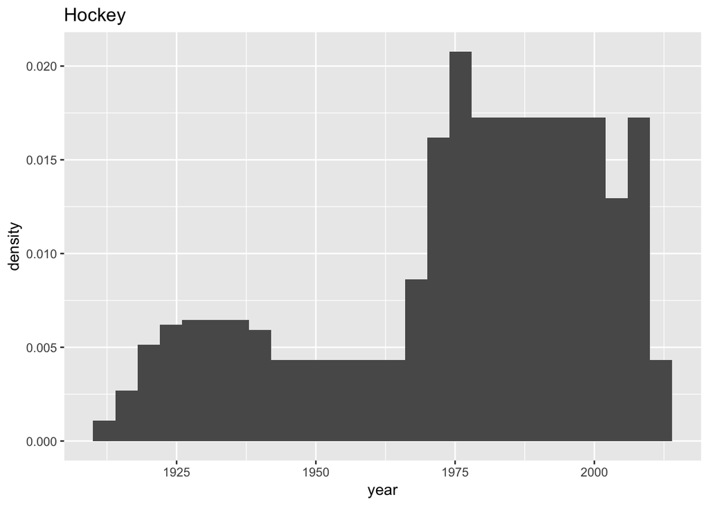

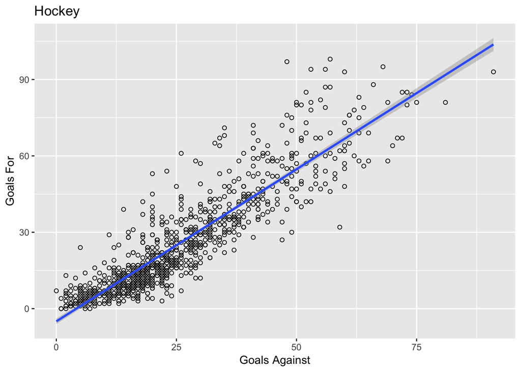

**Heart**

Dataset

```
## heart
##
##  14  Variables      303  Observations
## ---------------------------------------------------------------------------
## age
##        n  missing distinct     Info     Mean      Gmd      .05      .10
##      303        0       41    0.999    54.37    10.36     39.1     42.0
##      .25      .50      .75      .90      .95
##     47.5     55.0     61.0     66.0     68.0
##
## lowest : 29 34 35 37 38, highest: 70 71 74 76 77
## ---------------------------------------------------------------------------
## sex
##        n  missing distinct     Info      Sum     Mean      Gmd
##      303        0        2    0.649      207   0.6832   0.4343
##
## ---------------------------------------------------------------------------
## cp
##        n  missing distinct     Info     Mean      Gmd
##      303        0        4    0.866    0.967    1.105
##
## Value          0     1     2     3
## Frequency    143    50    87    23
## Proportion 0.472 0.165 0.287 0.076
## ---------------------------------------------------------------------------
## trestbps
##        n  missing distinct     Info     Mean      Gmd      .05      .10
##      303        0       49    0.995    131.6    19.32      108      110
##      .25      .50      .75      .90      .95
##      120      130      140      152      160
##
## lowest :  94 100 101 102 104, highest: 174 178 180 192 200
## ---------------------------------------------------------------------------
## chol
##        n  missing distinct     Info     Mean      Gmd      .05      .10
##      303        0      152        1    246.3    55.95    175.0    188.0
##      .25      .50      .75      .90      .95
##    211.0    240.0    274.5    308.8    326.9
##
## lowest : 126 131 141 149 157, highest: 394 407 409 417 564
```

[output cut: 49 more lines]

```
## Proportion 0.578 0.215 0.125 0.066 0.017
## ---------------------------------------------------------------------------
## thal
##        n  missing distinct     Info     Mean      Gmd
##      303        0        4    0.778    2.314   0.6125
##
## Value          0     1     2     3
## Frequency      2    18   166   117
## Proportion 0.007 0.059 0.548 0.386
## ---------------------------------------------------------------------------
## target
##        n  missing distinct     Info      Sum     Mean      Gmd
##      303        0        2    0.744      165   0.5446   0.4977
##
## ---------------------------------------------------------------------------
```

```
## [1] "data.frame"
```

```
##  [1] "age"      "sex"      "cp"       "trestbps" "chol"     "fbs"
##  [7] "restecg"  "thalach"  "exang"    "oldpeak"  "slope"    "ca"
## [13] "thal"     "target"
```

```
##    age cp trestbps chol fbs thalach
## 1   63  3      145  233   1     150
## 2   37  2      130  250   0     187
## 3   41  1      130  204   0     172
## 4   56  1      120  236   0     178
## 5   57  0      120  354   0     163
## 6   57  0      140  192   0     148
## 7   56  1      140  294   0     153
## 8   44  1      120  263   0     173
## 9   52  2      172  199   1     162
## 10  57  2      150  168   0     174
```

```
##     age cp trestbps chol fbs thalach
## 294  67  2      152  212   0     150
## 295  44  0      120  169   0     144
## 296  63  0      140  187   0     144
## 297  63  0      124  197   0     136
## 298  59  0      164  176   1      90
## 299  57  0      140  241   0     123
## 300  45  3      110  264   0     132
## 301  68  0      144  193   1     141
## 302  57  0      130  131   0     115
## 303  57  1      130  236   0     174
```

With the everchanging role that healthcare has had on our lives, it is important to take care of ourselves. I found this data set focusing around heart attacks and the data for patients.

The average cholesterol was given at 246.3 The average age of heart attack was given at 54. The avereage resting blood pressure was 131.6 The average maximum heart rate schieved was 149.65.

Given the average numbers made me realize that with the average age being 54, it is younger than I thought and it is important to pay attention to the other numbers as well to prevent future heart attacks and other health concerns. I was also looking closely at the cholesterol and was thinking it would be more centralized around one age group and during my analysis, I noticed it was random and it is shown within the graph.

Average cholesterol

```
## [1] 246.264
```

Average age

```
## [1] 54.36634
```

Average resting blood pressure

```
## [1] 131.6238
```

Avernge max heart rate

```
## [1] 149.6469
```

Graphs

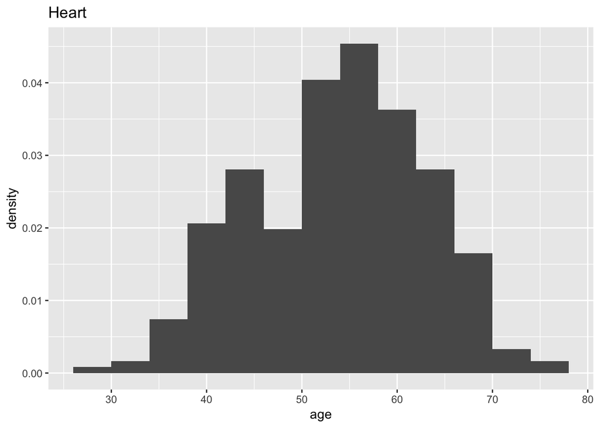

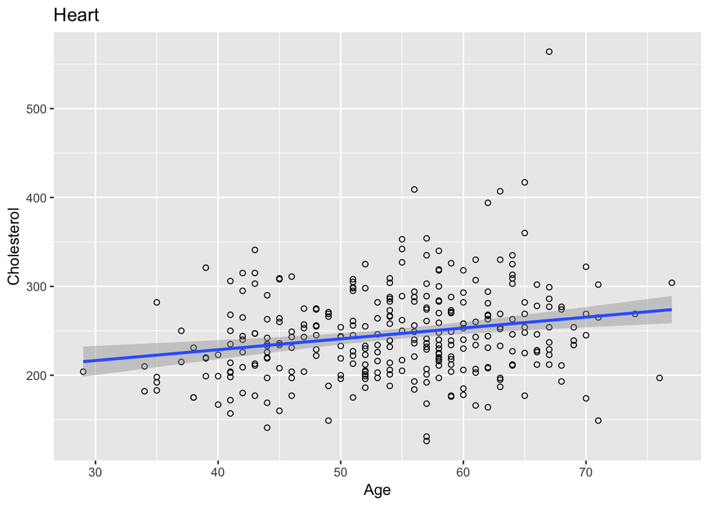

The information for this dataset was given with more information for analysis. It can be built upon with more research of the different symptoms and how the numbers change and also more data for different years to compare if things have gotten better or worse.